# Peer-graded Assignment: Regression Models

Nikhil

June 25, 2017

## Executive Summary

Miles per gallon (MPG) is an important criteria for assessing and rating automobiles. It depends of various factors: fuel quality, weight, number of cylinders, engine efficiency, transmission efficiency, driver ability, road conditions, etc. This report tries to explain the difference between the effect of automatic and manual transmission on MPG.

### Lets explore the data

- **Describe the dateset**: The **mtcars** dataset of contains information on various cars set on 11 variables namely: **mpg** (Miles per gallon), **cyl** (Number of cylinders), **disp** (Displacement cubic inches), **hp** (Gross horsepower), **drat** Rear axle ration, **wt** (Weight 1000lbs), **qsec** (1/4 mile time), **vs** (V/S), **am** (Transmission; 0 = automatic; 1 = manual ), **gear** (Number of forward gears) and **carb** (Number of carburetors).
- **Identify the key variables**: This report identifies the **mpg** and **am** variables as the key for the purpose of this report. Other variables particularly *cyl*, *gear* and *drat* would be considered for additional analysis.
- **Explore the dataset**: The mean **mpg** for when grouped by *automatic* and *manual* transmission are **17.14737** and **24.39231** respectively. We can infer that on an average **manual** transmission is **better** than **automatic** transmission. See figure for illustration.

### Is an automatic or manual transmission better for MPG?

### Quantifying the MPG difference between automatic and manual transmissions.

## R Markdown

```
## # A tibble: 2 x 2
##       am      mpg
##   <fctr>    <dbl>
## 1      0 17.14737
## 2      1 24.39231
```

```
## # A tibble: 6 x 3
## # Groups:   am [?]
##       am   cyl      mpg
##   <fctr> <dbl>    <dbl>
## 1      0     4 22.90000
## 2      0     6 19.12500
## 3      0     8 15.05000
## 4      1     4 28.07500
## 5      1     6 20.56667
## 6      1     8 15.40000
```

```
## # A tibble: 4 x 3
## # Groups:   am [?]
##       am  gear      mpg
##   <fctr> <dbl>    <dbl>
## 1      0     3 16.10667
## 2      0     4 21.05000
## 3      1     4 26.27500
## 4      1     5 21.38000
```

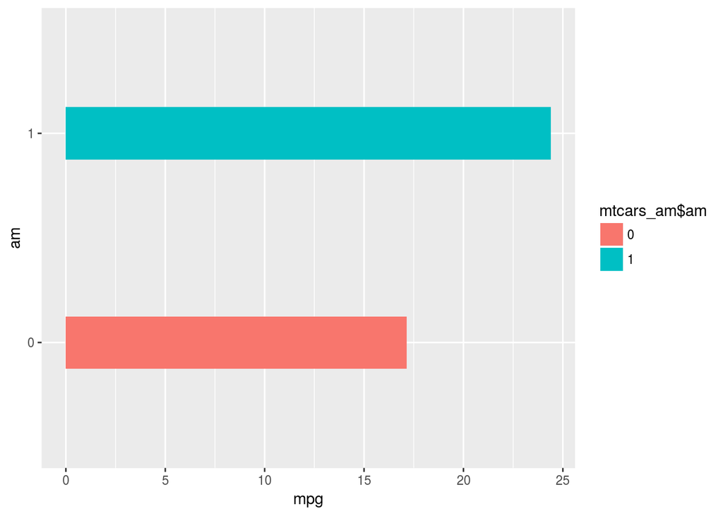

[figure not shown]

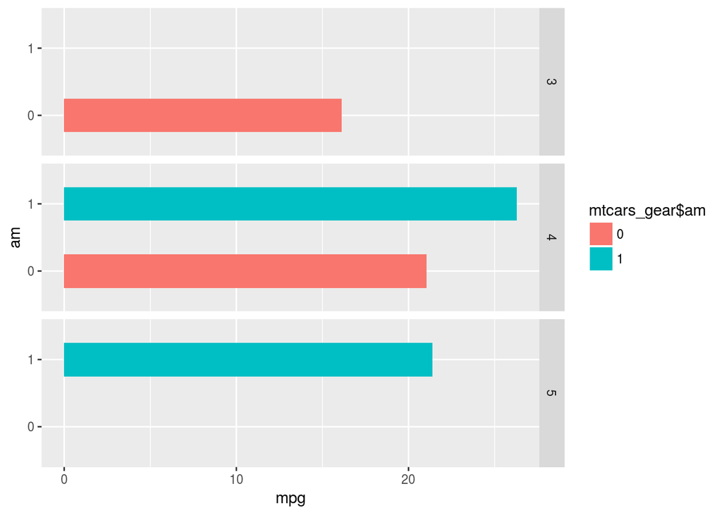

## Including Plots

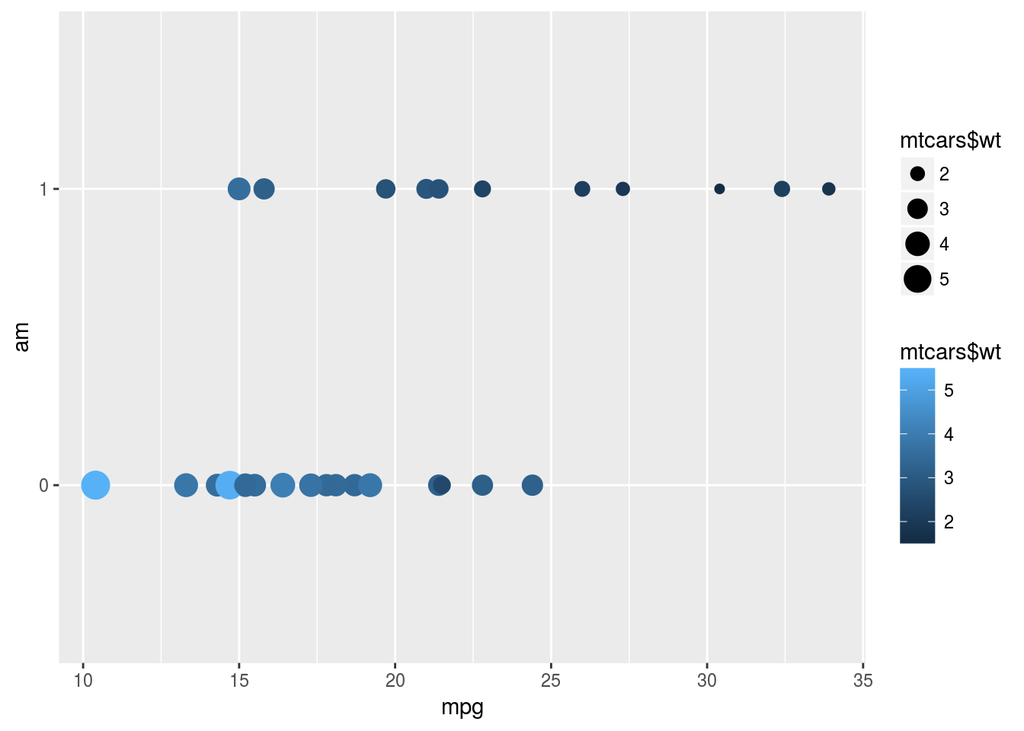

```r
library(ggplot2)
ggplot(data = mtcars, aes(x = mpg, y = am)) + geom_point(aes(size = mtcars$wt, colour = mtcars$wt))
```

```r
fit <- lm(mpg ~ am - 1, data = mtcars)

# fit

# plot(fit)

summary(fit)
```

```
##
## Call:
## lm(formula = mpg ~ am - 1, data = mtcars)
##
## Residuals:
##     Min      1Q  Median      3Q     Max
## -9.3923 -3.0923 -0.2974  3.2439  9.5077
##
## Coefficients:
##     Estimate Std. Error t value Pr(>|t|)
## am0   17.147      1.125   15.25 1.13e-15 ***
## am1   24.392      1.360   17.94  < 2e-16 ***
## ---
## Signif. codes:  0 '***' 0.001 '**' 0.01 '*' 0.05 '.' 0.1 ' ' 1
##
## Residual standard error: 4.902 on 30 degrees of freedom
## Multiple R-squared:  0.9487, Adjusted R-squared:  0.9452
## F-statistic: 277.2 on 2 and 30 DF,  p-value: < 2.2e-16
```

```r
fit2 <- lm(mpg ~ am + wt - 1, data = mtcars)

# fit2

summary(fit2)
```

```
##
## Call:
## lm(formula = mpg ~ am + wt - 1, data = mtcars)
##
## Residuals:
##     Min      1Q  Median      3Q     Max
## -4.5295 -2.3619 -0.1317  1.4025  6.8782
##
## Coefficients:
##     Estimate Std. Error t value Pr(>|t|)
## am0  37.3216     3.0546  12.218 5.84e-13 ***
## am1  37.2979     2.0857  17.883  < 2e-16 ***
## wt   -5.3528     0.7882  -6.791 1.87e-07 ***
## ---
## Signif. codes:  0 '***' 0.001 '**' 0.01 '*' 0.05 '.' 0.1 ' ' 1
##
## Residual standard error: 3.098 on 29 degrees of freedom
## Multiple R-squared:  0.9802, Adjusted R-squared:  0.9781
## F-statistic: 478.1 on 3 and 29 DF,  p-value: < 2.2e-16
```

```r
fit3 <- lm(mpg ~ am + cyl - 1, data = mtcars)

# fit3

summary(fit3)
```

```
##
## Call:
## lm(formula = mpg ~ am + cyl - 1, data = mtcars)
##
## Residuals:
##     Min      1Q  Median      3Q     Max
## -5.6856 -1.7172 -0.2657  1.8838  6.8144
##
## Coefficients:
##     Estimate Std. Error t value Pr(>|t|)
## am0  34.5224     2.6032  13.262 7.69e-14 ***
## am1  37.0895     2.0188  18.372  < 2e-16 ***
## cyl  -2.5010     0.3608  -6.931 1.28e-07 ***
## ---
## Signif. codes:  0 '***' 0.001 '**' 0.01 '*' 0.05 '.' 0.1 ' ' 1
##
## Residual standard error: 3.059 on 29 degrees of freedom
## Multiple R-squared:  0.9807, Adjusted R-squared:  0.9787
## F-statistic: 490.6 on 3 and 29 DF,  p-value: < 2.2e-16
```

```r
summary(lm(mpg ~ . -1, data = mtcars))
```

```
##
## Call:
## lm(formula = mpg ~ . - 1, data = mtcars)
##
## Residuals:
##     Min      1Q  Median      3Q     Max
## -3.4506 -1.6044 -0.1196  1.2193  4.6271
##
## Coefficients:
##      Estimate Std. Error t value Pr(>|t|)
## cyl  -0.11144    1.04502  -0.107   0.9161
## disp  0.01334    0.01786   0.747   0.4635
## hp   -0.02148    0.02177  -0.987   0.3350
## drat  0.78711    1.63537   0.481   0.6353
## wt   -3.71530    1.89441  -1.961   0.0633 .
## qsec  0.82104    0.73084   1.123   0.2739
## vs    0.31776    2.10451   0.151   0.8814
## am0  12.30337   18.71788   0.657   0.5181
## am1  14.82360   18.35265   0.808   0.4283
## gear  0.65541    1.49326   0.439   0.6652
## carb -0.19942    0.82875  -0.241   0.8122
## ---
## Signif. codes:  0 '***' 0.001 '**' 0.01 '*' 0.05 '.' 0.1 ' ' 1
##
## Residual standard error: 2.65 on 21 degrees of freedom
## Multiple R-squared:  0.9895, Adjusted R-squared:  0.984
## F-statistic: 179.8 on 11 and 21 DF,  p-value: < 2.2e-16
```